# A cool map

Pablo Ugarte

2017-09-20

# Intro

> In this post we will be plotting population in Spain using Hex Bins in ggplot2.

# Libraries

We will first load the packages.

```r
library(stringr) # Manipulating strings
library(tidyverse) # Data wrangling packages gather, spread...
library(maps) # Spatial Visualization
library(readr) # Read docs
library(RColorBrewer) # Colors
```

# Data

Data comes from MAXMIND [^1]. We select ES.zip file (for Spain). We remove cities with no population and rename columns.

# Plot

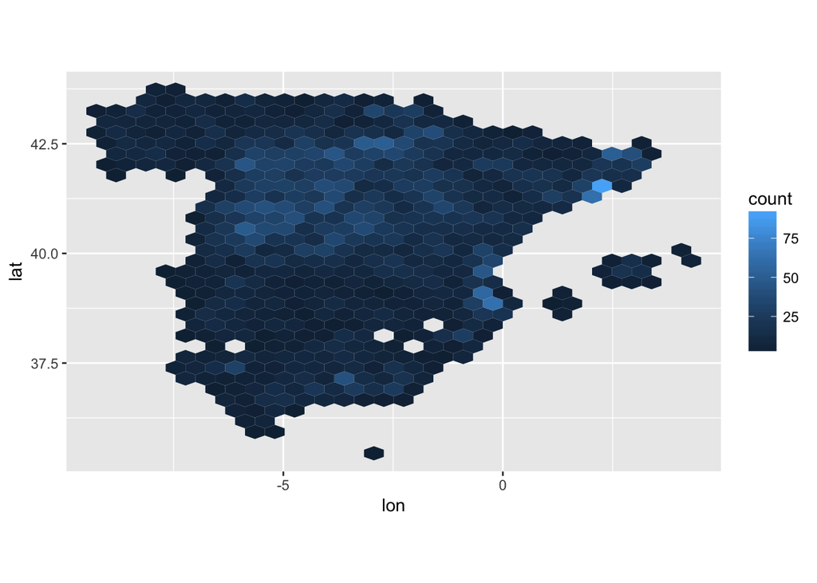

```r
s <-
    ggplot(spaincities, aes(x = lon, y = lat)) +
    geom_hex() +
    coord_equal()
s
```

Looks ok but not easy to compare different cities on a continuous scale.

Better to break the bins in levels with R base function cut(): it breaks a continuous variable into a factor.

[figure not shown]

```r
s <-
    ggplot(spaincities, aes(x = lon, y = lat)) +
    stat_binhex(
        colour = NA,
        aes(fill = cut(..count.., breaks =7))) +
    coord_equal() +
    labs(fill = NULL) +
    scale_fill_brewer(
        palette = "OrRed",
        labels = c('<50,000','50,000-100,000','100,000-200,000','200,000-500,000','500,000-1000,000', '1,000,000+'))

s
```

As expected, concentrations of population are found in the largest cities. We will now layer the largest cities on the map. To do this, we need to create a data frame with the names and coordinates info.

```r
bigcity <- data.frame(
    name = c("Madrid", "Barcelona", "Valencia", "Sevilla", "Zaragoza",
             "Malaga", "Murcia", "Palma", "Bilbao", "Valladolid", "Cordoba", "Vigo", "Gijon", "Granada", "La Coruña", "Vitoria"),
    long = c(-3.692220, 2.174100, -0.366667, -5.976133, -0.884861, -4.434802, -1.130042, 2.655222, -2.938764, -4.723720, -4.772748, -8.722637, -5.661519, -3.599201, -8.406812, -2.666667),
    lat  = c(40.40857, 41.39837, 39.46667, 37.38241, 41.64531, 36.72667, 37.98704, 39.57434, 43.26092, 41.65518, 37.89155, 42.23282, 43.53573, 37.17835, 43.36661, 42.85000),
    vjust = c(0, 1, 1, 1, 0, 0.5, 0.5, 0, 1, 1, 1, 1, 1, 1, 1, 1),
    hjust = 0.5)
```

We use geom_text to overlay names on the ggplot.

[figure not shown]

```r
s <- s + labs(title = "Spain, most populated cities") +
    geom_text(aes(x = long, y = lat, label = name, vjust = vjust,
                  hjust = hjust), data = bigcity, size = 3.8) +
    theme(panel.background = element_rect(fill = "NA", colour = NA),
          plot.background = element_rect(fill = "NA", colour = NA),
          # Remove titles, ticks, gridlines, and borders
          axis.text = element_blank(),
          axis.title = element_blank(),
          axis.ticks = element_blank(),
          panel.grid = element_blank(),
          panel.border = element_blank(),
          # Set the legend background
          legend.position = c(0.9,0.25),
          legend.direction = "vertical",
          legend.background = element_rect(fill = NA, colour = NA),
          legend.key = element_rect(fill = NA, colour = NA),
          legend.key.size = unit(1, "line"),
          # Set margins so that the graphic fills the whole space.
          plot.margin = unit(c(0, 0, -0.5, -0.5), "line"))
s
```

And we have have the plot! As you can see the plot can be done with a few lines of code. The rest is minor adjustment to make it more beautiful.

[^1]: MAXMIND (http://download.geonames.org/export/dump/)